# Global Development Analytics & Predictive Decision System

### Analyzing and Predicting GDP per Capita Using SQL, Python & Machine Learning

## Project Overview

This project analyzes country-level development patterns using selected indicators from the **World Development Indicators (WDI)** dataset.

The objective is to understand how economic, demographic, digital, labour-market and trade-related indicators are associated with **GDP per capita**, and to examine whether information from the previous year can be used to predict GDP per capita in the following year.

The project combines exploratory analysis, statistical analysis and machine learning to move from understanding historical development patterns to evaluating predictive performance.

### Project Journey

**World Bank → DataHub → Excel → MySQL / SQL → Python → Statistical Analysis → Machine Learning → Prediction Gap Analysis → Decision Support**

### Analysis Period

**2010–2024**

### Unit of Analysis

Each observation represents a **country-year**, meaning one country or economy measured during one specific year.

World Bank regional, income-group and other aggregate entities are excluded from the country-level predictive analysis.

### Target Variable

**GDP per capita (constant 2015 US$)**

### Development Indicators

1. Population Growth
2. Life Expectancy
3. Internet Usage
4. Unemployment
5. Exports as % of GDP

### Predictive Question

**Can previous-year GDP per capita and historical development indicators be used to predict a country's GDP per capita in the following year?**

### Predictive Approach

The project compares:

- **Naive Baseline** — previous-year GDP only
- **Indicators-Only Models** — five previous-year development indicators
- **Full Models** — previous-year GDP combined with the five development indicators

### Signature Analysis

**Global Development Progression Funnel**

**Observe → Explain → Predict → Diagnose → Support Decisions**

## Business Problem & Analytical Questions

### Business Problem

Countries differ considerably in their economic and development conditions. Understanding how development indicators are associated with GDP per capita can help identify broader development patterns.

This project also examines whether historical information can provide useful predictions of GDP per capita for the following year.

The analysis therefore addresses both **descriptive and predictive questions** rather than relying only on model performance.

### Analytical Questions

- How does GDP per capita vary across countries and years?
- How are population growth, life expectancy, internet usage, unemployment and exports as a percentage of GDP associated with GDP per capita?
- Which development indicators show stronger statistical relationships with GDP per capita?
- Can the five development indicators from the previous year predict GDP per capita in the following year?
- How does an indicators-only model compare with a simple previous-year GDP baseline?
- How does predictive performance change when previous-year GDP is added to the development indicators?
- Where are the larger differences between predicted and actual GDP per capita?

### Analytical Approach

**EDA → Statistical Analysis → Next-Year Prediction → Model Comparison → Prediction Gap Analysis → Decision Support**

The predictive analysis uses a **time-based train–test approach**, with earlier observations used for training and later observations from **2023–2024** used for testing.

The analysis identifies statistical relationships and predictive patterns. It does **not** claim that the selected indicators directly cause changes in GDP per capita or represent official economic forecasts.

## Dataset & Variable Definitions

### Country

**Country_Name** identifies the country or economy represented by each observation.

**Country_Code** provides the corresponding country/economy code.

For the country-level predictive analysis, World Bank regional, income-group and other aggregate entities are excluded.

### Year

**Year** identifies the year in which the development indicators were measured.

Each row represents a **country-year observation**.

### Target Variable — GDP per Capita

**GDP_per_capita**

GDP per capita represents GDP divided by the population of the economy.

**Measurement:** Constant 2015 US dollars

The use of constant prices adjusts the series for price changes over time, allowing GDP per capita to be compared across years using 2015 prices.

### Predictor 1 — Population Growth

**Population_growth**

Measures the annual percentage change in population.

**Measurement:** Percentage (%)

### Predictor 2 — Life Expectancy

**Life_expectancy**

Measures the expected number of years a newborn would live under the mortality conditions prevailing at the time of measurement.

**Measurement:** Years

### Predictor 3 — Internet Usage

**Internet_usage**

Measures the share of the population using the Internet.

**Measurement:** Percentage (%)

### Predictor 4 — Unemployment

**Unemployment**

Measures unemployment as a share of the labour force.

**Measurement:** Percentage (%)

### Predictor 5 — Exports as % of GDP

**Exports_pct_GDP**

Measures exports of goods and services relative to the size of the economy.

**Measurement:** Percentage of GDP (%)

### Variable Summary

| Variable | Role | Measurement |
| --- | --- | --- |
| Country_Name | Identifier | Country |
| Country_Code | Identifier | Code |
| Year | Time | Year |
| GDP_per_capita | Target | Constant 2015 US$ |
| Population_growth | Predictor | % |
| Life_expectancy | Predictor | Years |
| Internet_usage | Predictor | % |
| Unemployment | Predictor | % |
| Exports_pct_GDP | Predictor | % of GDP |

## Data Journey & Technology Stack

### Data Journey

The dataset was not taken directly into Python. It followed a multi-stage preparation and validation process:

**World Bank WDI** ↓  
**DataHub** ↓  
**Excel — Data Preparation** ↓  
**MySQL — Data Storage** ↓  
**SQL — Data Validation** ↓  
**Python — EDA & Statistical Analysis** ↓  
**Country-Level Data Preparation** ↓  
**Lagged Variables & Next-Year Prediction Dataset** ↓  
**Machine Learning** ↓  
**Prediction Gap Analysis** ↓  
**Power BI — Decision Support**

### SQL Validation Completed Before Python

The dataset was validated in MySQL using:

- Record counts
- Country coverage
- Year range using `MIN()` and `MAX()`
- Missing-value checks
- Duplicate checks
- Basic value and range checks

Python therefore begins with the **validated SQL dataset** rather than repeating the complete SQL validation process.

### Predictive Data Preparation

Before predictive modeling:

- World Bank aggregate entities were removed.
- Lagged variables were created using previous-year observations.
- Non-consecutive year gaps were excluded from the lagged prediction data.
- A time-based train–test split was used, with **2011–2022 for training** and **2023–2024 for testing**.

### Technology Stack

**Excel | MySQL | SQL | Python | Pandas | NumPy | Matplotlib | Seaborn | SciPy | Scikit-learn | Power BI **

```python
# ============================================================
# 5. IMPORT LIBRARIES
# ============================================================

import pandas as pd
import numpy as np

import matplotlib.pyplot as plt
import seaborn as sns

from scipy import stats

from sklearn.linear_model import LinearRegression
from sklearn.ensemble import RandomForestRegressor
from sklearn.metrics import mean_absolute_error, mean_squared_error, r2_score

pd.set_option("display.max_columns", None)
pd.set_option("display.float_format", "{:,.2f}".format)

sns.set_theme(style="whitegrid")

print("Libraries imported successfully.")
```

```
Libraries imported successfully.
```

```python
# ============================================================
# 6. CONNECT PYTHON TO MYSQL
# ============================================================

import mysql.connector

connection = mysql.connector.connect(
    host="localhost",
    user="root",
    password="_________",
    database="global_development"
)

print("Connected to MySQL successfully.")
```

```
Connected to MySQL successfully.
```

```python
# ============================================================
# 7. LOAD VALIDATED DATA FROM MYSQL
# ============================================================

query = """
SELECT
    Country_Name,
    Country_Code,
    Year,
    GDP_per_capita,
    Population_growth,
    Life_expectancy,
    Internet_usage,
    Unemployment,
    Exports_pct_GDP
FROM development_data
"""

df = pd.read_sql(query, connection)

print("Validated dataset loaded successfully.")
print("Rows:", f"{df.shape[0]:,}")
print("Columns:", df.shape[1])
```

```
Validated dataset loaded successfully.
Rows: 2,844
Columns: 9
```

```python
# ============================================================
# 8. PREPARE VARIABLES FOR ANALYSIS
# ============================================================

df["Year"] = pd.to_numeric(df["Year"], errors="coerce")

numeric_columns = [
    "GDP_per_capita",
    "Population_growth",
    "Life_expectancy",
    "Internet_usage",
    "Unemployment",
    "Exports_pct_GDP"
]

for col in numeric_columns:
    df[col] = pd.to_numeric(df[col], errors="coerce")

# Round values for clean presentation
df["GDP_per_capita"] = df["GDP_per_capita"].round(2)

for col in [
    "Population_growth",
    "Internet_usage",
    "Unemployment",
    "Exports_pct_GDP"
]:
    df[col] = df[col].round(2)

df["Life_expectancy"] = df["Life_expectancy"].round(2)

print("Variables converted to numeric format.")
print("GDP per capita: constant 2015 US$")
print("Population growth: %")
print("Life expectancy: years")
print("Internet usage: %")
print("Unemployment: %")
print("Exports: % of GDP")
```

```
Variables converted to numeric format.
GDP per capita: constant 2015 US$
Population growth: %
Life expectancy: years
Internet usage: %
Unemployment: %
Exports: % of GDP
```

```python
# ============================================================
# 9. FIRST LOOK AT THE ANALYTICAL DATASET
# ============================================================

df.head()
```

|  | Country_Name | Country_Code | Year | GDP_per_capita | Population_growth | Life_expectancy | Internet_usage | Unemployment | Exports_pct_GDP |
| --- | --- | --- | --- | --- | --- | --- | --- | --- | --- |
| 0 | Afghanistan | AFG | 2020 | 527.83 | 3.15 | 61.45 | 17.05 | 11.71 | 10.42 |
| 1 | Afghanistan | AFG | 2021 | 408.63 | 2.36 | 60.42 | 16.51 | 12.01 | 14.34 |
| 2 | Afghanistan | AFG | 2022 | 377.67 | 1.44 | 65.62 | 15.87 | 14.10 | 18.38 |
| 3 | Afghanistan | AFG | 2023 | 378.07 | 2.14 | 66.04 | 15.93 | 14.01 | 16.24 |
| 4 | Afghanistan | AFG | 2024 | 374.38 | 2.84 | 66.29 | 16.09 | 13.69 | 15.70 |

```python
# ============================================================
# 10. DATASET STRUCTURE
# ============================================================

print("Dataset Shape:", df.shape)

print("\nData Types:")
print(df.dtypes)
```

```
Dataset Shape: (2844, 9)

Data Types:
Country_Name             str
Country_Code             str
Year                   int64
GDP_per_capita       float64
Population_growth    float64
Life_expectancy      float64
Internet_usage       float64
Unemployment         float64
Exports_pct_GDP      float64
dtype: object
```

```python
# ============================================================
# 11. DESCRIPTIVE OVERVIEW
# ============================================================

df.describe().T
```

|  | count | mean | std | min | 25% | 50% | 75% | max |
| --- | --- | --- | --- | --- | --- | --- | --- | --- |
| Year | 2,844.00 | 2,016.90 | 4.30 | 2,010.00 | 2,013.00 | 2,017.00 | 2,021.00 | 2,024.00 |
| GDP_per_capita | 2,844.00 | 13,906.41 | 19,114.01 | 349.82 | 1,742.11 | 5,743.32 | 17,202.83 | 110,873.12 |
| Population_growth | 2,844.00 | 1.29 | 1.40 | -10.93 | 0.43 | 1.19 | 2.20 | 14.23 |
| Life_expectancy | 2,844.00 | 72.02 | 7.82 | 18.82 | 66.68 | 73.29 | 77.89 | 85.53 |
| Internet_usage | 2,844.00 | 52.64 | 29.72 | 0.58 | 25.00 | 55.45 | 79.49 | 100.00 |
| Unemployment | 2,844.00 | 7.47 | 5.49 | 0.10 | 3.99 | 5.88 | 9.09 | 36.47 |
| Exports_pct_GDP | 2,844.00 | 40.28 | 30.56 | 0.00 | 22.13 | 31.55 | 48.30 | 340.30 |

## Exploratory Data Analysis

The exploratory analysis examines the distribution, variation, relationships and trends of GDP per capita and the five selected development indicators.

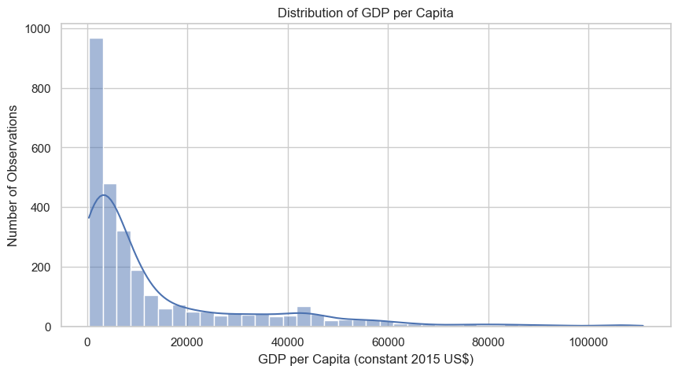

```python
# ============================================================
# GDP PER CAPITA DISTRIBUTION
# ============================================================

plt.figure(figsize=(10, 5))

sns.histplot(
    df["GDP_per_capita"].dropna(),
    bins=40,
    kde=True
)

plt.title("Distribution of GDP per Capita")
plt.xlabel("GDP per Capita (constant 2015 US$)")
plt.ylabel("Number of Observations")

plt.show()
```

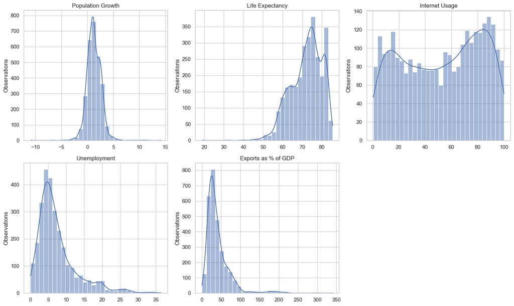

```python
# ============================================================
# DISTRIBUTION OF THE FIVE DEVELOPMENT INDICATORS
# ============================================================

fig, axes = plt.subplots(2, 3, figsize=(15, 9))

predictors = [
    "Population_growth",
    "Life_expectancy",
    "Internet_usage",
    "Unemployment",
    "Exports_pct_GDP"
]

titles = [
    "Population Growth",
    "Life Expectancy",
    "Internet Usage",
    "Unemployment",
    "Exports as % of GDP"
]

for ax, col, title in zip(axes.flatten(), predictors, titles):
    sns.histplot(df[col].dropna(), bins=30, kde=True, ax=ax)
    ax.set_title(title)
    ax.set_xlabel("")
    ax.set_ylabel("Observations")

# Remove unused sixth subplot
axes.flatten()[-1].axis("off")

plt.tight_layout()
plt.show()
```

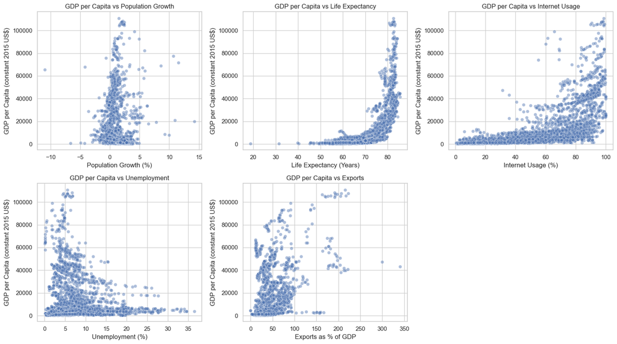

```python
# ============================================================
# GDP PER CAPITA vs FIVE DEVELOPMENT INDICATORS
# ============================================================

predictors = [
    "Population_growth",
    "Life_expectancy",
    "Internet_usage",
    "Unemployment",
    "Exports_pct_GDP"
]

titles = [
    "GDP per Capita vs Population Growth",
    "GDP per Capita vs Life Expectancy",
    "GDP per Capita vs Internet Usage",
    "GDP per Capita vs Unemployment",
    "GDP per Capita vs Exports"
]

x_labels = [
    "Population Growth (%)",
    "Life Expectancy (Years)",
    "Internet Usage (%)",
    "Unemployment (%)",
    "Exports as % of GDP"
]

fig, axes = plt.subplots(2, 3, figsize=(16, 9))

for ax, predictor, title, x_label in zip(
    axes.flatten(),
    predictors,
    titles,
    x_labels
):
    sns.scatterplot(
        data=df,
        x=predictor,
        y="GDP_per_capita",
        alpha=0.45,
        ax=ax
    )

    ax.set_title(title)
    ax.set_xlabel(x_label)
    ax.set_ylabel("GDP per Capita (constant 2015 US$)")

# Remove unused sixth subplot
axes.flatten()[-1].axis("off")

plt.tight_layout()
plt.show()
```

## EDA Insights

The exploratory analysis helps identify the major patterns in the dataset before moving into statistical analysis and predictive modeling.

### Key Observations

> **Important:** These are exploratory relationships. Correlation or association does not establish causation.

## Statistical Analysis — Pearson Correlation

Pearson correlation is used to measure the **strength and direction of the linear relationship** between GDP per capita and each of the five development indicators.

**How it helps this project:** It provides an initial statistical understanding of which development indicators are more strongly associated with GDP per capita, helping us interpret the relationships before moving into **multiple regression and predictive modeling**.

The analysis reports:

- **Pearson correlation coefficient (r)** — strength and direction of the relationship.
- **p-value** — statistical significance of the observed relationship.

> **Important:** Correlation shows association, not causation.

```python
# ============================================================
#   PEARSON CORRELATION & SIGNIFICANCE TEST
# ============================================================

predictors = [
    "Population_growth",
    "Life_expectancy",
    "Internet_usage",
    "Unemployment",
    "Exports_pct_GDP"
]

correlation_results = []

for predictor in predictors:

    temp = df[["GDP_per_capita", predictor]].dropna()

    r, p_value = stats.pearsonr(
        temp["GDP_per_capita"],
        temp[predictor]
    )

    correlation_results.append({
        "Predictor": predictor,
        "Pearson_r": r,
        "p_value": p_value
    })

correlation_results = pd.DataFrame(correlation_results)

correlation_results["Relationship"] = np.where(
    correlation_results["Pearson_r"] > 0,
    "Positive",
    "Negative"
)

correlation_results["Significant_at_5pct"] = np.where(
    correlation_results["p_value"] < 0.05,
    "Yes",
    "No"
)

correlation_results.sort_values(
    by="Pearson_r",
    ascending=False
)
```

|  | Predictor | Pearson_r | p_value | Relationship | Significant_at_5pct |
| --- | --- | --- | --- | --- | --- |
| 1 | Life_expectancy | 0.66 | 0.00 | Positive | Yes |
| 2 | Internet_usage | 0.64 | 0.00 | Positive | Yes |
| 4 | Exports_pct_GDP | 0.49 | 0.00 | Positive | Yes |
| 0 | Population_growth | -0.12 | 0.00 | Negative | Yes |
| 3 | Unemployment | -0.14 | 0.00 | Negative | Yes |

## Statistical Analysis — Multiple Linear Regression

Multiple Linear Regression is used to examine the combined relationship between GDP per capita and the five selected development indicators.

This analysis provides a statistical benchmark before moving to the next-year predictive modeling stage.

```python
# ============================================================
#   MULTIPLE LINEAR REGRESSION
# ============================================================

from sklearn.linear_model import LinearRegression
from sklearn.metrics import r2_score, mean_absolute_error, mean_squared_error

regression_columns = [
    "GDP_per_capita",
    "Population_growth",
    "Life_expectancy",
    "Internet_usage",
    "Unemployment",
    "Exports_pct_GDP"
]

regression_df = df[regression_columns].dropna()

X = regression_df[
    [
        "Population_growth",
        "Life_expectancy",
        "Internet_usage",
        "Unemployment",
        "Exports_pct_GDP"
    ]
]

y = regression_df["GDP_per_capita"]

# Fit multiple linear regression
linear_model = LinearRegression()
linear_model.fit(X, y)

# Predictions
y_pred = linear_model.predict(X)

# Model performance
r2 = r2_score(y, y_pred)
mae = mean_absolute_error(y, y_pred)
rmse = np.sqrt(mean_squared_error(y, y_pred))

# Coefficients
coefficients = pd.DataFrame({
    "Predictor": X.columns,
    "Coefficient": linear_model.coef_
})

print("Multiple Linear Regression Results")
print("=" * 50)

print(f"R² Score : {r2:.3f}")
print(f"MAE      : {mae:,.2f}")
print(f"RMSE     : {rmse:,.2f}")

print("\nRegression Coefficients:")
display(coefficients)
```

```
Multiple Linear Regression Results
==================================================
R² Score : 0.561
MAE      : 9,045.85
RMSE     : 12,657.27

Regression Coefficients:
```

|  | Predictor | Coefficient |
| --- | --- | --- |
| 0 | Population_growth | 2,349.37 |
| 1 | Life_expectancy | 942.98 |
| 2 | Internet_usage | 200.13 |
| 3 | Unemployment | -315.85 |
| 4 | Exports_pct_GDP | 149.83 |

## Predictive Modeling — Next-Year GDP Prediction

## Prediction Approach

The predictive analysis is designed to answer the following question:

> **Given a country's economic and development conditions in one year, what GDP per capita would the model predict for the following year?**

Instead of using indicators from the same year to predict that year's GDP per capita, the model uses **previous-year information** to predict the GDP per capita of the following year.

### How the Historical Data Is Used

The dataset covers **2010–2024**. Each year provides historical information that can be used to create a next-year prediction.

For example:

**2010 indicators → Predict 2011 GDP per capita**  
**2011 indicators → Predict 2012 GDP per capita**  
**2022 indicators → Predict 2023 GDP per capita**  
**2023 indicators → Predict 2024 GDP per capita**

Therefore, the earlier years are not discarded. They provide the historical observations required for the model to learn development patterns over time.

### Predictor Structure

For each country-year observation:

**Previous-year GDP per capita**

- **Previous-year Population Growth**
- **Previous-year Life Expectancy**
- **Previous-year Internet Usage**
- **Previous-year Unemployment**
- **Previous-year Exports as % of GDP**

↓

**Current-year GDP per capita**

### Time-Based Train–Test Split

A **time-based train–test split** is used because the objective is to predict future GDP per capita using information available from the past.

The model is trained using **earlier years** and evaluated using **later, unseen years**.

This preserves the chronological order of the data and prevents future observations from being used to train the model before they are evaluated.

### Why This Approach?

This creates a realistic predictive workflow:

**Historical Development Conditions → Next-Year GDP Prediction → Actual vs Predicted GDP → Prediction Gap Analysis**

The actual GDP per capita values are kept unchanged. The model is evaluated based on how closely its predictions match the observed values.

## World Bank Aggregate Filtering

The World Bank dataset contains both **individual countries/economies** and **aggregate entities**, such as regions, income groups and global totals.

For this project, the unit of analysis is the **country-year observation**. Therefore, aggregate entities were removed before creating lagged variables and building the predictive models.

This step ensures that the analysis focuses on **individual country-level development patterns** and prevents regional or income-group aggregates from being treated as individual countries.

Filtering the aggregates before lag creation is important because the lagged variables are calculated within each country. Keeping aggregate entities could otherwise introduce non-country observations into the predictive dataset.

After filtering, the dataset contains only the country/economy observations used for the subsequent **next-year prediction analysis**.

```python
# ============================================================
# REMOVE WORLD BANK AGGREGATE ENTITIES
# ============================================================
# The World Bank dataset contains both individual countries
# and regional/income-group aggregates.
# For country-level predictive analysis, we keep only
# individual country/economy observations.

aggregate_codes = [
    "AFE", "AFW", "ARB", "CEB", "CSS", "EAR", "EAS",
    "EAP", "EMU", "ECS", "ECA", "EUU", "FCS", "HPC",
    "HIC", "IBD", "IBT", "IDA", "IDB", "IDX", "INX",
    "LAC", "LCN", "LDC", "LIC", "LMC", "LMY", "LTE",
    "MEA", "MIC", "MNA", "NAC", "OED", "OSS", "PRE",
    "PSS", "PST", "SAS", "SSF", "SSA", "SST", "TEA",
    "TEC", "TLA", "TMN", "TSA", "TSS", "UMC", "WLD"
]

df = df[~df["Country_Code"].isin(aggregate_codes)].copy()

print("Dataset after removing World Bank aggregate entities:")
print(f"Rows: {len(df):,}")
print(f"Countries/Economies: {df['Country_Code'].nunique():,}")
print(f"Year range: {df['Year'].min()}–{df['Year'].max()}")
```

```
Dataset after removing World Bank aggregate entities:
Rows: 2,395
Countries/Economies: 173
Year range: 2010–2024
```

```python
# Check remaining country/economy codes
df[["Country_Name", "Country_Code"]].drop_duplicates().head(20)
```

|  | Country_Name | Country_Code |
| --- | --- | --- |
| 0 | Afghanistan | AFG |
| 20 | Albania | ALB |
| 35 | Algeria | DZA |
| 50 | Angola | AGO |
| 65 | Argentina | ARG |
| 80 | Armenia | ARM |
| 95 | Australia | AUS |
| 110 | Austria | AUT |
| 125 | Azerbaijan | AZE |
| 140 | Bahamas, The | BHS |
| 155 | Bahrain | BHR |
| 170 | Bangladesh | BGD |
| 185 | Belarus | BLR |
| 200 | Belgium | BEL |
| 215 | Belize | BLZ |
| 230 | Benin | BEN |
| 245 | Bhutan | BTN |
| 260 | Bolivia | BOL |
| 275 | Bosnia and Herzegovina | BIH |
| 290 | Botswana | BWA |

```python
# ============================================================
# CREATE LAGGED VARIABLES FOR NEXT-YEAR PREDICTION
# ============================================================
# Lagged variables represent the previous year's values.
# A lag is kept only when the previous observation is exactly
# one calendar year earlier.

df = df.sort_values(["Country_Code", "Year"]).copy()

lag_columns = [
    "GDP_per_capita",
    "Population_growth",
    "Life_expectancy",
    "Internet_usage",
    "Unemployment",
    "Exports_pct_GDP"
]

# Create previous-observation lags
for col in lag_columns:
    df[f"{col}_lag1"] = df.groupby("Country_Code")[col].shift(1)

# Check whether the lag is exactly one calendar year earlier
df["Lag_Year"] = df.groupby("Country_Code")["Year"].shift(1)

invalid_mask = df["Lag_Year"].notna() & ((df["Year"] - df["Lag_Year"]) != 1)

# Remove non-consecutive lags
lagged_columns = [f"{col}_lag1" for col in lag_columns]
df.loc[invalid_mask, lagged_columns] = np.nan

print(f"Non-consecutive lag observations excluded: {invalid_mask.sum():,}")

# Remove helper column
df.drop(columns=["Lag_Year"], inplace=True)
```

```
Non-consecutive lag observations excluded: 10
```

```python
# ============================================================
# CREATE NEXT-YEAR PREDICTION DATASET
# ============================================================

model_features = [
    "GDP_per_capita_lag1",
    "Population_growth_lag1",
    "Life_expectancy_lag1",
    "Internet_usage_lag1",
    "Unemployment_lag1",
    "Exports_pct_GDP_lag1"
]

target = "GDP_per_capita"

model_df = df[
    ["Country_Name", "Country_Code", "Year"] +
    model_features +
    [target]
].dropna().copy()

print("Modeling dataset shape:", model_df.shape)
print("\nPrediction period:")
print(model_df["Year"].min(), "to", model_df["Year"].max())

model_df.head()
```

```
Modeling dataset shape: (2212, 10)

Prediction period:
2011 to 2024
```

|  | Country_Name | Country_Code | Year | GDP_per_capita_lag1 | Population_growth_lag1 | Life_expectancy_lag1 | Internet_usage_lag1 | Unemployment_lag1 | Exports_pct_GDP_lag1 | GDP_per_capita |
| --- | --- | --- | --- | --- | --- | --- | --- | --- | --- | --- |
| 1 | Afghanistan | AFG | 2021 | 527.83 | 3.15 | 61.45 | 17.05 | 11.71 | 10.42 | 408.63 |
| 2 | Afghanistan | AFG | 2022 | 408.63 | 2.36 | 60.42 | 16.51 | 12.01 | 14.34 | 377.67 |
| 3 | Afghanistan | AFG | 2023 | 377.67 | 1.44 | 65.62 | 15.87 | 14.10 | 18.38 | 378.07 |
| 4 | Afghanistan | AFG | 2024 | 378.07 | 2.14 | 66.04 | 15.93 | 14.01 | 16.24 | 374.38 |
| 51 | Angola | AGO | 2011 | 3,540.79 | 3.85 | 57.24 | 2.80 | 16.60 | 53.89 | 3,528.17 |

```python
# ============================================================
# VERIFY LAGGED PREDICTION STRUCTURE
# ============================================================

model_df[
    [
        "Country_Name",
        "Year",
        "GDP_per_capita_lag1",
        "GDP_per_capita"
    ]
].head(15)
```

|  | Country_Name | Year | GDP_per_capita_lag1 | GDP_per_capita |
| --- | --- | --- | --- | --- |
| 1 | Afghanistan | 2021 | 527.83 | 408.63 |
| 2 | Afghanistan | 2022 | 408.63 | 377.67 |
| 3 | Afghanistan | 2023 | 377.67 | 378.07 |
| 4 | Afghanistan | 2024 | 378.07 | 374.38 |
| 51 | Angola | 2011 | 3,540.79 | 3,528.17 |
| 52 | Angola | 2012 | 3,528.17 | 3,682.35 |
| 53 | Angola | 2013 | 3,682.35 | 3,716.30 |
| 54 | Angola | 2014 | 3,716.30 | 3,746.82 |
| 55 | Angola | 2015 | 3,746.82 | 3,641.73 |
| 56 | Angola | 2016 | 3,641.73 | 3,505.60 |
| 57 | Angola | 2017 | 3,505.60 | 3,378.08 |
| 58 | Angola | 2018 | 3,378.08 | 3,246.88 |
| 59 | Angola | 2019 | 3,246.88 | 3,105.60 |
| 60 | Angola | 2020 | 3,105.60 | 2,847.24 |
| 61 | Angola | 2021 | 2,847.24 | 2,788.17 |

```python
# ============================================================
# TRAIN / TEST SPLIT — TIME BASED
# ============================================================

train_df = model_df[model_df["Year"] <= 2022].copy()
test_df = model_df[model_df["Year"] >= 2023].copy()

X_train = train_df[model_features]
y_train = train_df[target]

X_test = test_df[model_features]
y_test = test_df[target]

print("Training data:", X_train.shape)
print("Testing data :", X_test.shape)

print("\nTraining years:",
      train_df["Year"].min(), "to", train_df["Year"].max())

print("Testing years :",
      test_df["Year"].min(), "to", test_df["Year"].max())
```

```
Training data: (1913, 6)
Testing data : (299, 6)

Training years: 2011 to 2022
Testing years : 2023 to 2024
```

```python
# ============================================================
#  FULL MODEL — LINEAR REGRESSION
# ============================================================

linear_model = LinearRegression()

linear_model.fit(X_train, y_train)

y_pred_linear = linear_model.predict(X_test)

linear_mae = mean_absolute_error(y_test, y_pred_linear)
linear_rmse = np.sqrt(mean_squared_error(y_test, y_pred_linear))
linear_r2 = r2_score(y_test, y_pred_linear)

print("Linear Regression Results")
print("-" * 40)
print(f"MAE  : {linear_mae:,.2f}")
print(f"RMSE : {linear_rmse:,.2f}")
print(f"R²   : {linear_r2:.3f}")
```

```
Linear Regression Results
----------------------------------------
MAE  : 376.84
RMSE : 1,555.56
R²   : 0.995
```

```python
# ============================================================
#  FULL MODEL — RANDOM FOREST
# ============================================================

rf_model = RandomForestRegressor(
    n_estimators=300,
    random_state=42,
    n_jobs=-1
)

rf_model.fit(X_train, y_train)

y_pred_rf = rf_model.predict(X_test)

rf_mae = mean_absolute_error(y_test, y_pred_rf)
rf_rmse = np.sqrt(mean_squared_error(y_test, y_pred_rf))
rf_r2 = r2_score(y_test, y_pred_rf)

print("Random Forest Results")
print("-" * 40)
print(f"MAE  : {rf_mae:,.2f}")
print(f"RMSE : {rf_rmse:,.2f}")
print(f"R²   : {rf_r2:.3f}")
```

```
Random Forest Results
----------------------------------------
MAE  : 496.79
RMSE : 1,592.21
R²   : 0.994
```

```python
# ============================================================
# NAIVE BASELINE — PERSISTENCE MODEL (no ML, just last year's GDP)
# ============================================================

y_pred_naive = test_df["GDP_per_capita_lag1"]

naive_mae  = mean_absolute_error(y_test, y_pred_naive)
naive_rmse = np.sqrt(mean_squared_error(y_test, y_pred_naive))
naive_r2   = r2_score(y_test, y_pred_naive)

print("Naive Baseline (Predicted = Previous Year's GDP)")
print("-" * 50)
print(f"MAE  : {naive_mae:,.2f}")
print(f"RMSE : {naive_rmse:,.2f}")
print(f"R²   : {naive_r2:.3f}")
```

```
Naive Baseline (Predicted = Previous Year's GDP)
--------------------------------------------------
MAE  : 398.85
RMSE : 1,584.59
R²   : 0.994
```

```python
# ============================================================
# MODEL WITHOUT GDP LAG — INDICATORS-ONLY PREDICTION
# ============================================================

indicator_features = [
    "Population_growth_lag1",
    "Life_expectancy_lag1",
    "Internet_usage_lag1",
    "Unemployment_lag1",
    "Exports_pct_GDP_lag1"
]

X_train_ind = train_df[indicator_features]
X_test_ind  = test_df[indicator_features]

# Linear Regression — indicators only
linear_model_ind = LinearRegression()
linear_model_ind.fit(X_train_ind, y_train)
y_pred_linear_ind = linear_model_ind.predict(X_test_ind)

linear_ind_mae  = mean_absolute_error(y_test, y_pred_linear_ind)
linear_ind_rmse = np.sqrt(mean_squared_error(y_test, y_pred_linear_ind))
linear_ind_r2   = r2_score(y_test, y_pred_linear_ind)

# Random Forest — indicators only
rf_model_ind = RandomForestRegressor(n_estimators=300, random_state=42, n_jobs=-1)
rf_model_ind.fit(X_train_ind, y_train)
y_pred_rf_ind = rf_model_ind.predict(X_test_ind)

rf_ind_mae  = mean_absolute_error(y_test, y_pred_rf_ind)
rf_ind_rmse = np.sqrt(mean_squared_error(y_test, y_pred_rf_ind))
rf_ind_r2   = r2_score(y_test, y_pred_rf_ind)

print("Indicators-Only Models (no GDP lag)")
print("-" * 50)
print(f"Linear Regression -> MAE: {linear_ind_mae:,.2f} | RMSE: {linear_ind_rmse:,.2f} | R²: {linear_ind_r2:.3f}")
print(f"Random Forest      -> MAE: {rf_ind_mae:,.2f} | RMSE: {rf_ind_rmse:,.2f} | R²: {rf_ind_r2:.3f}")
```

```
Indicators-Only Models (no GDP lag)
--------------------------------------------------
Linear Regression -> MAE: 13,027.97 | RMSE: 15,936.26 | R²: 0.428
Random Forest      -> MAE: 5,550.14 | RMSE: 8,820.87 | R²: 0.825
```

```python
# ============================================================
# ACTUAL VS PREDICTED GDP PER CAPITA
# ============================================================

prediction_results = test_df[
    ["Country_Name", "Country_Code", "Year", "GDP_per_capita"]
].copy()

prediction_results["Predicted_Linear"] = y_pred_linear
prediction_results["Predicted_Random_Forest"] = y_pred_rf

prediction_results["Linear_Gap"] = (
    prediction_results["Predicted_Linear"]
    - prediction_results["GDP_per_capita"]
)

prediction_results["RF_Gap"] = (
    prediction_results["Predicted_Random_Forest"]
    - prediction_results["GDP_per_capita"]
)

prediction_results.head(15)
```

|  | Country_Name | Country_Code | Year | GDP_per_capita | Predicted_Linear | Predicted_Random_Forest | Linear_Gap | RF_Gap |
| --- | --- | --- | --- | --- | --- | --- | --- | --- |
| 3 | Afghanistan | AFG | 2023 | 378.07 | 404.55 | 397.53 | 26.48 | 19.46 |
| 4 | Afghanistan | AFG | 2024 | 374.38 | 322.13 | 392.12 | -52.25 | 17.74 |
| 63 | Angola | AGO | 2023 | 2,748.95 | 2,697.93 | 2,856.20 | -51.02 | 107.25 |
| 64 | Angola | AGO | 2024 | 2,798.59 | 2,657.48 | 2,811.93 | -141.11 | 13.34 |
| 33 | Albania | ALB | 2023 | 6,204.44 | 6,345.84 | 5,956.32 | 141.40 | -248.12 |
| 34 | Albania | ALB | 2024 | 6,549.23 | 6,691.92 | 6,290.99 | 142.69 | -258.24 |
| 2662 | United Arab Emirates | ARE | 2023 | 41,926.58 | 41,727.65 | 42,046.93 | -198.93 | 120.35 |
| 78 | Argentina | ARG | 2023 | 12,993.09 | 13,616.22 | 13,483.41 | 623.13 | 490.32 |
| 79 | Argentina | ARG | 2024 | 12,774.35 | 13,316.19 | 12,950.15 | 541.84 | 175.80 |
| 93 | Armenia | ARM | 2023 | 5,197.24 | 5,069.32 | 5,005.33 | -127.92 | -191.91 |
| 94 | Armenia | ARM | 2024 | 5,378.32 | 5,519.40 | 5,307.43 | 141.08 | -70.89 |
| 108 | Australia | AUS | 2023 | 61,869.08 | 61,538.52 | 59,395.39 | -330.56 | -2,473.69 |
| 109 | Australia | AUS | 2024 | 61,486.38 | 62,080.08 | 58,845.82 | 593.70 | -2,640.56 |
| 123 | Austria | AUT | 2023 | 46,497.91 | 47,680.31 | 48,054.66 | 1,182.40 | 1,556.75 |
| 124 | Austria | AUT | 2024 | 45,958.83 | 46,839.26 | 47,144.80 | 880.43 | 1,185.97 |

```python
# ============================================================
# INDIA 2024 — ACTUAL VS PREDICTED GDP
# ============================================================

india_2024 = prediction_results[
    (prediction_results["Country_Name"] == "India") &
    (prediction_results["Year"] == 2024)
].copy()

india_2024[
    [
        "Country_Name",
        "Year",
        "GDP_per_capita",
        "Predicted_Linear",
        "Predicted_Random_Forest",
        "Linear_Gap",
        "RF_Gap"
    ]
]
```

|  | Country_Name | Year | GDP_per_capita | Predicted_Linear | Predicted_Random_Forest | Linear_Gap | RF_Gap |
| --- | --- | --- | --- | --- | --- | --- | --- |
| 1225 | India | 2024 | 2,366.83 | 2,429.21 | 2,301.32 | 62.38 | -65.51 |

```python
# ============================================================
# PREDICTION GAP ANALYSIS
# ============================================================

prediction_results["RF_Absolute_Gap"] = (
    prediction_results["RF_Gap"].abs()
)

prediction_results["RF_Percentage_Error"] = (
    prediction_results["RF_Absolute_Gap"]
    / prediction_results["GDP_per_capita"]
) * 100

prediction_results.sort_values(
    "RF_Absolute_Gap",
    ascending=False
).head(10)
```

|  | Country_Name | Country_Code | Year | GDP_per_capita | Predicted_Linear | Predicted_Random_Forest | Linear_Gap | RF_Gap | RF_Absolute_Gap | RF_Percentage_Error |
| --- | --- | --- | --- | --- | --- | --- | --- | --- | --- | --- |
| 1605 | Macao SAR, China | MAC | 2023 | 59,474.40 | 34,502.82 | 35,806.10 | -24,971.58 | -23,668.30 | 23,668.30 | 39.80 |
| 1284 | Ireland | IRL | 2023 | 93,541.96 | 98,187.40 | 98,866.64 | 4,645.44 | 5,324.68 | 5,324.68 | 5.69 |
| 2266 | Singapore | SGP | 2023 | 65,976.71 | 68,445.02 | 71,261.78 | 2,468.31 | 5,285.07 | 5,285.07 | 8.01 |
| 1285 | Ireland | IRL | 2024 | 94,474.99 | 93,937.69 | 98,309.33 | -537.30 | 3,834.34 | 3,834.34 | 4.06 |
| 109 | Australia | AUS | 2024 | 61,486.38 | 62,080.08 | 58,845.82 | 593.70 | -2,640.56 | 2,640.56 | 4.29 |
| 1910 | New Zealand | NZL | 2024 | 41,415.47 | 42,672.81 | 44,053.49 | 1,257.34 | 2,638.02 | 2,638.02 | 6.37 |
| 1684 | Malta | MLT | 2023 | 33,429.82 | 31,590.91 | 30,897.02 | -1,838.91 | -2,532.80 | 2,532.80 | 7.58 |
| 108 | Australia | AUS | 2023 | 61,869.08 | 61,538.52 | 59,395.39 | -330.56 | -2,473.69 | 2,473.69 | 4.00 |
| 1209 | Iceland | ISL | 2023 | 59,951.75 | 57,830.50 | 57,513.41 | -2,121.25 | -2,438.34 | 2,438.34 | 4.07 |
| 1591 | Luxembourg | LUX | 2024 | 104,147.11 | 105,858.29 | 106,535.35 | 1,711.18 | 2,388.24 | 2,388.24 | 2.29 |

```python
# ============================================================
# OVERALL PREDICTION GAP METRICS
# ============================================================

mean_absolute_gap = prediction_results["RF_Absolute_Gap"].mean()
median_absolute_gap = prediction_results["RF_Absolute_Gap"].median()
mean_percentage_error = prediction_results["RF_Percentage_Error"].mean()
median_percentage_error = prediction_results["RF_Percentage_Error"].median()

print("Random Forest Prediction Gap Analysis")
print("-" * 45)
print(f"Mean Absolute Gap     : ${mean_absolute_gap:,.2f}")
print(f"Median Absolute Gap   : ${median_absolute_gap:,.2f}")
print(f"Mean Percentage Error : {mean_percentage_error:.2f}%")
print(f"Median Percentage Error: {median_percentage_error:.2f}%")
```

```
Random Forest Prediction Gap Analysis
---------------------------------------------
Mean Absolute Gap     : $496.79
Median Absolute Gap   : $139.69
Mean Percentage Error : 2.93%
Median Percentage Error: 2.30%
```

```python
# ============================================================
# FULL MODEL COMPARISON — BASELINE vs INDICATORS-ONLY vs FULL MODEL
# ============================================================

full_comparison = pd.DataFrame({
    "Model": [
        "Naive Baseline (last year's GDP)",
        "Linear Regression (indicators only)",
        "Random Forest (indicators only)",
        "Linear Regression (indicators + GDP lag)",
        "Random Forest (indicators + GDP lag)"
    ],
    "MAE":  [naive_mae, linear_ind_mae, rf_ind_mae, linear_mae, rf_mae],
    "RMSE": [naive_rmse, linear_ind_rmse, rf_ind_rmse, linear_rmse, rf_rmse],
    "R2":   [naive_r2, linear_ind_r2, rf_ind_r2, linear_r2, rf_r2]
})

full_comparison
```

|  | Model | MAE | RMSE | R2 |
| --- | --- | --- | --- | --- |
| 0 | Naive Baseline (last year's GDP) | 398.85 | 1,584.59 | 0.99 |
| 1 | Linear Regression (indicators only) | 13,027.97 | 15,936.26 | 0.43 |
| 2 | Random Forest (indicators only) | 5,550.14 | 8,820.87 | 0.82 |
| 3 | Linear Regression (indicators + GDP lag) | 376.84 | 1,555.56 | 0.99 |
| 4 | Random Forest (indicators + GDP lag) | 496.79 | 1,592.21 | 0.99 |

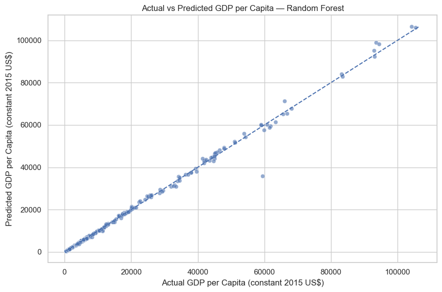

```python
# ============================================================
# ACTUAL VS PREDICTED GDP — RANDOM FOREST
# ============================================================

plt.figure(figsize=(9, 6))

sns.scatterplot(
    x=prediction_results["GDP_per_capita"],
    y=prediction_results["Predicted_Random_Forest"],
    alpha=0.6
)

# Perfect prediction reference line
min_value = min(
    prediction_results["GDP_per_capita"].min(),
    prediction_results["Predicted_Random_Forest"].min()
)

max_value = max(
    prediction_results["GDP_per_capita"].max(),
    prediction_results["Predicted_Random_Forest"].max()
)

plt.plot(
    [min_value, max_value],
    [min_value, max_value],
    linestyle="--"
)

plt.title("Actual vs Predicted GDP per Capita — Random Forest")
plt.xlabel("Actual GDP per Capita (constant 2015 US$)")
plt.ylabel("Predicted GDP per Capita (constant 2015 US$)")

plt.tight_layout()
plt.show()
```

## Key Findings & Implications

The analysis focused on two main questions: how the selected development indicators are related to GDP per capita, and how useful these indicators are for predicting GDP per capita one year ahead.

### Decision Support Perspective

The prediction stage is intended to provide an **analytical benchmark rather than an official economic forecast**. Comparing predicted GDP per capita with actual values helps identify observations where the model's estimate differs from the observed outcome.

The **Prediction Gap Analysis** highlights country-year observations with larger differences between predicted and actual GDP per capita. These observations can be examined further using additional economic, demographic, policy and country-specific information that is outside the scope of this project.

The comparison between indicators-only and full models is also important. It shows the predictive contribution of the five selected development indicators separately from the strong year-to-year persistence of GDP per capita.

Overall, the results indicate that the selected development indicators contain useful predictive information, but they are not sufficient on their own to predict GDP per capita with the same level of accuracy as models that also use previous-year GDP.

> **The results represent statistical relationships and analytical predictions, not causal explanations or official economic forecasts.**

## Limitations

- The analysis focuses on five selected development indicators and therefore does not capture all economic, social, demographic and policy factors that may be associated with GDP per capita.
- The full models include previous-year GDP per capita, which is highly persistent over time. Therefore, their strong predictive performance should not be interpreted as evidence that the five development indicators alone can predict GDP per capita with similar accuracy.
- The indicators-only models provide a more direct assessment of the predictive information contained in the selected development indicators, but their performance is lower than that of the full models.
- The prediction framework uses previous-year information to estimate the following year's GDP per capita. Unexpected events such as economic shocks, crises or policy changes during the prediction year are not captured by the selected predictors.
- The dataset covers **2010–2024**, so the findings are based on this historical period and may not necessarily apply to other periods.
- Data availability varies across countries, resulting in different numbers of observations between economies.
- The analysis identifies statistical relationships and predictive patterns but does not establish causal relationships between the development indicators and GDP per capita.
- Prediction gaps indicate where model estimates differ from observed values, but the gap itself does not explain the underlying economic reasons for the difference.
- The results should therefore be interpreted as **analytical predictions and benchmarks rather than official economic forecasts**.

## Final Conclusion

This project developed an end-to-end **Global Development Analytics & Predictive Decision System**, beginning with World Bank data and progressing through Excel preparation, MySQL/SQL validation, Python-based exploratory analysis, statistical analysis and machine learning.

The analysis examined GDP per capita in relation to five development indicators: population growth, life expectancy, internet usage, unemployment and exports as a percentage of GDP.

For prediction, the project used a **time-based train–test approach**, training the models on historical observations from **2011–2022** and evaluating them on later, unseen observations from **2023–2024**. This preserves the chronological structure of the data and provides a more realistic framework for next-year prediction.

Rather than relying on a single model score, the project compared three different prediction approaches:

1. **Naive Baseline** — uses previous-year GDP per capita to predict the following year.
2. **Indicators-Only Models** — use the five lagged development indicators without GDP per capita.
3. **Full Models** — combine the five development indicators with previous-year GDP per capita.

The comparison shows that the five development indicators contain useful predictive information, particularly when modeled using Random Forest. At the same time, the strong performance of the full models and the naive baseline demonstrates the importance of GDP's year-to-year persistence.

The project also applied the analysis to **India 2024** and used **Prediction Gap Analysis** to identify country-year observations where predicted GDP per capita differed from the observed value. These gaps provide useful starting points for further investigation using additional economic and country-specific information.

The key lesson from the predictive analysis is that **model performance should always be interpreted in context**. A high R² does not necessarily mean that the selected development indicators alone explain GDP per capita, particularly when previous-year GDP is included in the model.

Overall, the project demonstrates an end-to-end analytics workflow that moves from **data preparation and validation to statistical analysis, prediction and decision-oriented interpretation**.

### Analytical Framework

**Observe → Explain → Predict → Diagnose → Support Decisions**

```python
prediction_results.columns.tolist()
```

```
['Country_Name',
 'Country_Code',
 'Year',
 'GDP_per_capita',
 'Predicted_Linear',
 'Predicted_Random_Forest',
 'Linear_Gap',
 'RF_Gap',
 'RF_Absolute_Gap',
 'RF_Percentage_Error']
```

```python
# ============================================================
# CREATE FINAL POWER BI PREDICTION DATASET
# ============================================================

powerbi_prediction = prediction_results.copy()

# Actual GDP
actual = powerbi_prediction["GDP_per_capita"]

# Linear Regression prediction
linear_pred = powerbi_prediction["Predicted_Linear"]

# Random Forest prediction
rf_pred = powerbi_prediction["Predicted_Random_Forest"]

# Calculate prediction gaps
powerbi_prediction["Linear_Gap"] = actual - linear_pred
powerbi_prediction["Linear_Absolute_Gap"] = (
    powerbi_prediction["Linear_Gap"].abs()
)

powerbi_prediction["Linear_Percentage_Error"] = (
    powerbi_prediction["Linear_Absolute_Gap"] / actual
) * 100

powerbi_prediction["Random_Forest_Gap"] = actual - rf_pred

powerbi_prediction["Random_Forest_Absolute_Gap"] = (
    powerbi_prediction["Random_Forest_Gap"].abs()
)

powerbi_prediction["Random_Forest_Percentage_Error"] = (
    powerbi_prediction["Random_Forest_Absolute_Gap"] / actual
) * 100

# Rename columns for Power BI
powerbi_prediction = powerbi_prediction.rename(columns={
    "GDP_per_capita": "Actual_GDP_per_capita",
    "Predicted_Linear": "Predicted_Linear_Regression",
    "Predicted_Random_Forest": "Predicted_Random_Forest"
})

# Keep only the columns needed for Power BI
powerbi_prediction = powerbi_prediction[
    [
        "Country_Name",
        "Country_Code",
        "Year",
        "Actual_GDP_per_capita",
        "Predicted_Linear_Regression",
        "Predicted_Random_Forest",
        "Linear_Gap",
        "Linear_Absolute_Gap",
        "Linear_Percentage_Error",
        "Random_Forest_Gap",
        "Random_Forest_Absolute_Gap",
        "Random_Forest_Percentage_Error"
    ]
]

# Export CSV
powerbi_prediction.to_csv(
    "PowerBI_Prediction_Data.csv",
    index=False
)

print("Power BI prediction dataset exported successfully.")
print(f"Rows: {len(powerbi_prediction):,}")
print("\nColumns:")
print(powerbi_prediction.columns.tolist())
```

```
Power BI prediction dataset exported successfully.
Rows: 299

Columns:
['Country_Name', 'Country_Code', 'Year', 'Actual_GDP_per_capita', 'Predicted_Linear_Regression', 'Predicted_Random_Forest', 'Linear_Gap', 'Linear_Absolute_Gap', 'Linear_Percentage_Error', 'Random_Forest_Gap', 'Random_Forest_Absolute_Gap', 'Random_Forest_Percentage_Error']
```

```python
powerbi_prediction.head()
```

|  | Country_Name | Country_Code | Year | Actual_GDP_per_capita | Predicted_Linear_Regression | Predicted_Random_Forest | Linear_Gap | Linear_Absolute_Gap | Linear_Percentage_Error | Random_Forest_Gap | Random_Forest_Absolute_Gap | Random_Forest_Percentage_Error |
| --- | --- | --- | --- | --- | --- | --- | --- | --- | --- | --- | --- | --- |
| 3 | Afghanistan | AFG | 2023 | 378.07 | 404.55 | 397.53 | -26.48 | 26.48 | 7.00 | -19.46 | 19.46 | 5.15 |
| 4 | Afghanistan | AFG | 2024 | 374.38 | 322.13 | 392.12 | 52.25 | 52.25 | 13.96 | -17.74 | 17.74 | 4.74 |
| 63 | Angola | AGO | 2023 | 2,748.95 | 2,697.93 | 2,856.20 | 51.02 | 51.02 | 1.86 | -107.25 | 107.25 | 3.90 |
| 64 | Angola | AGO | 2024 | 2,798.59 | 2,657.48 | 2,811.93 | 141.11 | 141.11 | 5.04 | -13.34 | 13.34 | 0.48 |
| 33 | Albania | ALB | 2023 | 6,204.44 | 6,345.84 | 5,956.32 | -141.40 | 141.40 | 2.28 | 248.12 | 248.12 | 4.00 |

```python
import os

print(os.getcwd())
```

```
C:\Users\User
```

```python
from IPython.display import FileLink

FileLink("PowerBI_Prediction_Data.csv")
```

PowerBI_Prediction_Data.csv

```python
from IPython.display import FileLink

powerbi_prediction.to_csv(
    "PowerBI_Prediction_Data.csv",
    index=False
)

FileLink("PowerBI_Prediction_Data.csv")
```

PowerBI_Prediction_Data.csv

```python
# Export a clean comma-delimited CSV for Power BI

powerbi_prediction.to_csv(
    "PowerBI_Prediction_Data.csv",
    index=False,
    sep=",",
    encoding="utf-8-sig"
)

print("CSV created successfully.")
```

```
CSV created successfully.
```

```python
from IPython.display import FileLink

FileLink("PowerBI_Prediction_Data.csv")
```

PowerBI_Prediction_Data.csv

```python
# ============================================================
# EXPORT MAIN DEVELOPMENT DATA FOR POWER BI
# ============================================================

powerbi_development = df[
    [
        "Country_Name",
        "Country_Code",
        "Year",
        "GDP_per_capita",
        "Population_growth",
        "Life_expectancy",
        "Internet_usage",
        "Unemployment",
        "Exports_pct_GDP"
    ]
].copy()

powerbi_development.to_csv(
    "PowerBI_Development_Data.csv",
    index=False,
    encoding="utf-8-sig"
)

print("Development dataset exported successfully.")
print(f"Rows: {len(powerbi_development):,}")
print(f"Countries: {powerbi_development['Country_Code'].nunique():,}")
print(f"Years: {powerbi_development['Year'].min()}–{powerbi_development['Year'].max()}")
```

```
Development dataset exported successfully.
Rows: 2,395
Countries: 173
Years: 2010–2024
```

```python
from IPython.display import FileLink

FileLink("PowerBI_Development_Data.csv")
```

PowerBI_Development_Data.csv

```python
# ============================================================
# CREATE MODEL COMPARISON DATASET FOR POWER BI
# ============================================================

model_comparison = pd.DataFrame({
    "Model": [
        "Naive Baseline — Previous GDP",
        "Indicators Only — Linear Regression",
        "Indicators Only — Random Forest",
        "Full Model — Linear Regression",
        "Full Model — Random Forest"
    ],
    "MAE": [
        398.85,
        13027.97,
        5550.14,
        376.84,
        496.79
    ],
    "RMSE": [
        1584.59,
        15936.26,
        8820.87,
        1555.56,
        1592.21
    ],
    "R2": [
        0.994,
        0.428,
        0.825,
        0.995,
        0.994
    ]
})

# Export for Power BI
model_comparison.to_csv(
    "PowerBI_Model_Comparison.csv",
    index=False,
    encoding="utf-8-sig"
)

print("Model comparison dataset exported successfully.")
print(model_comparison)
```

```
Model comparison dataset exported successfully.
                                 Model       MAE      RMSE   R2
0        Naive Baseline — Previous GDP    398.85  1,584.59 0.99
1  Indicators Only — Linear Regression 13,027.97 15,936.26 0.43
2      Indicators Only — Random Forest  5,550.14  8,820.87 0.82
3       Full Model — Linear Regression    376.84  1,555.56 0.99
4           Full Model — Random Forest    496.79  1,592.21 0.99
```

```python
from IPython.display import FileLink

FileLink("PowerBI_Model_Comparison.csv")
```

PowerBI_Model_Comparison.csv